# Analysis of SyriaTel performance in the Telecommunication Industry

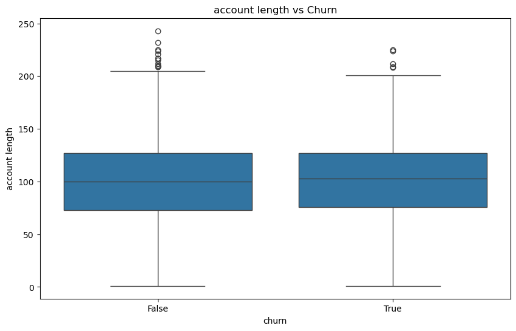

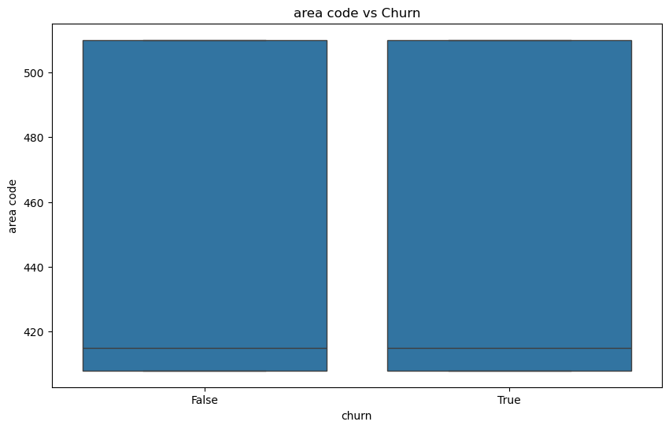

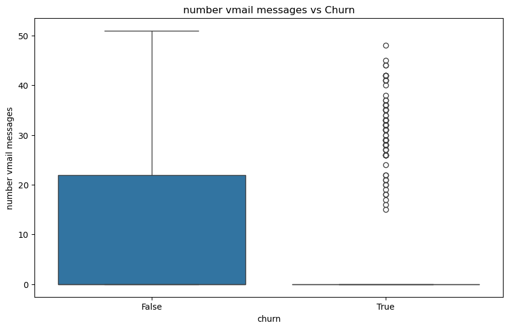

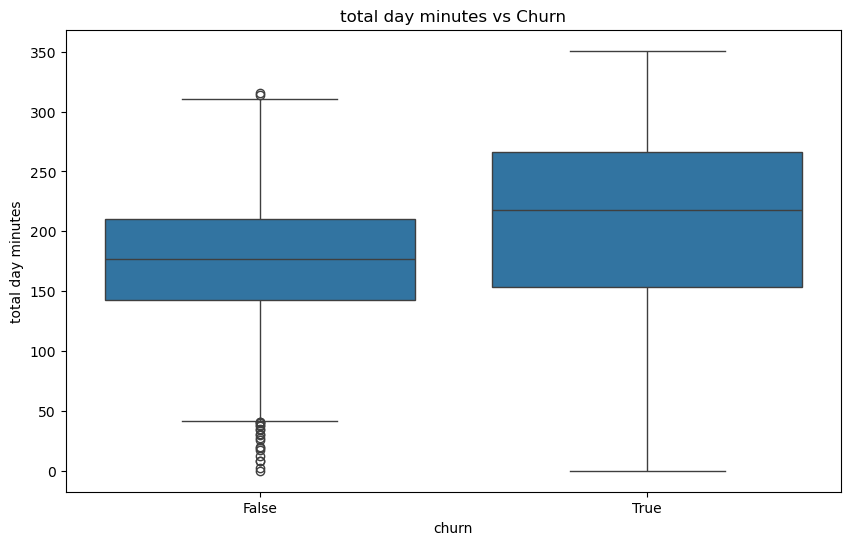

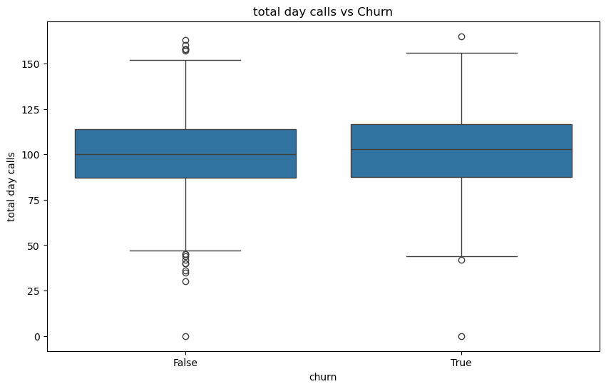

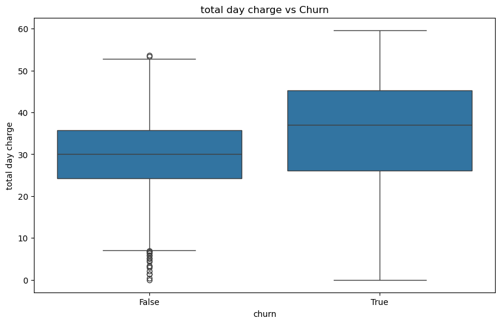

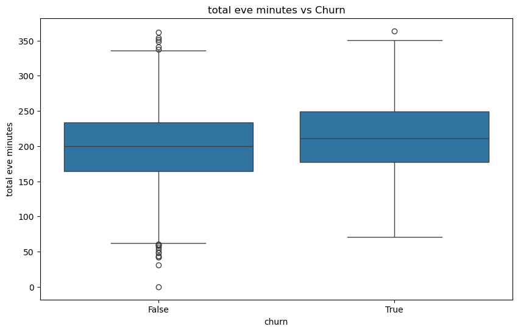

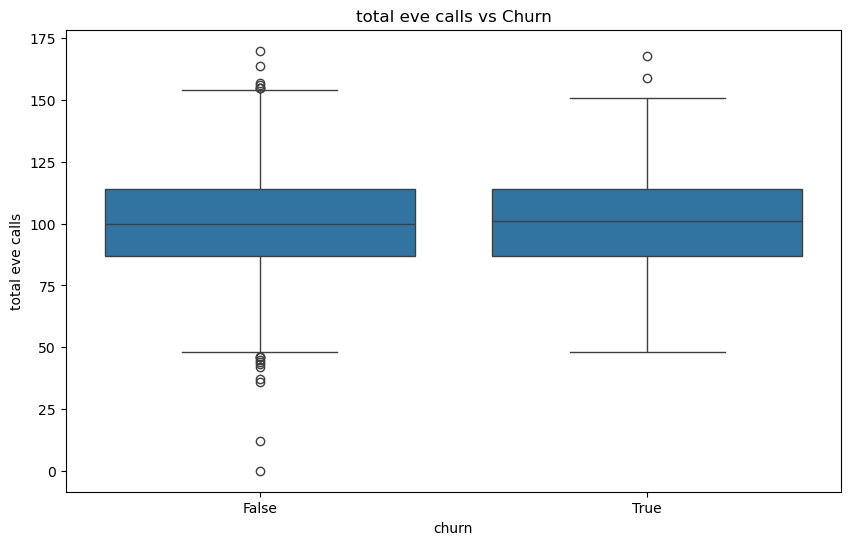

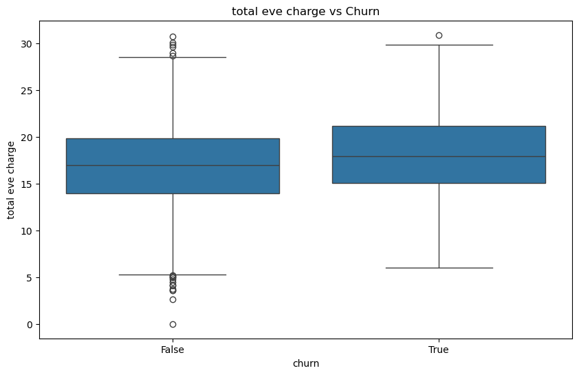

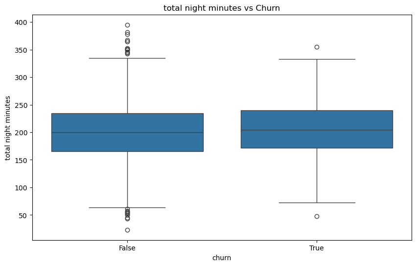

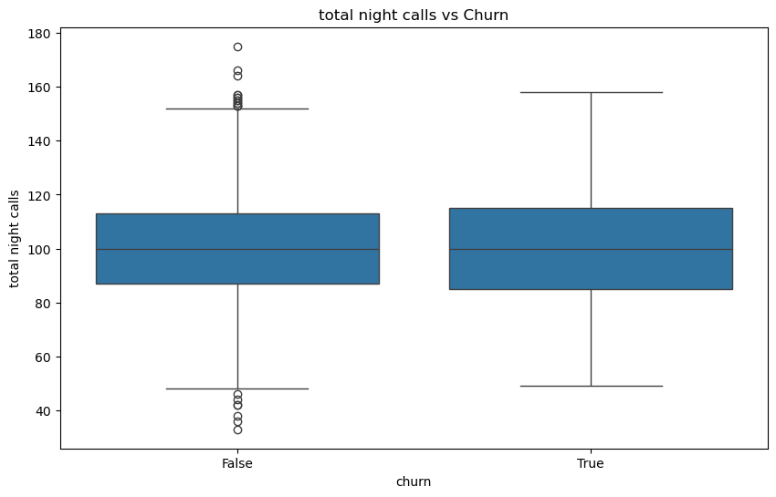

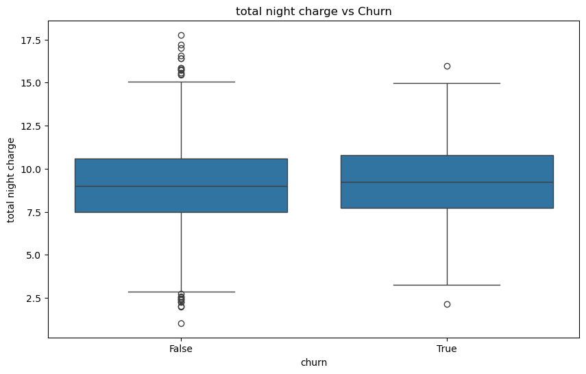

[4 more figures not shown]

```python
# Boxplot for numeric variable vs churn
for column in numeric_columns:
    plt.figure(figsize=(10, 6))
    sns.boxplot(data=df, x='churn', y=column)
    plt.title(f'{column} vs Churn')
    plt.show()
```

Feature Engineering

```python
df['total_usage_minutes'] = df['total day minutes'] + df['total eve minutes'] + df['total night minutes'] + df['total intl minutes']
df['total_charges'] = df['total day charge'] + df['total eve charge'] + df['total night charge'] + df['total intl charge']
```

PROCESSING

Handle Missing Data

```python
# Check for missing values
missing_data = df.isnull().sum()
print(missing_data)

# Drop rows with missing values
df = df.dropna()

# Fill missing values with a constant value
df.fillna(0, inplace=True)
```

```
state                     0
account length            0
area code                 0
phone number              0
international plan        0
voice mail plan           0
number vmail messages     0
total day minutes         0
total day calls           0
total day charge          0
total eve minutes         0
total eve calls           0
total eve charge          0
total night minutes       0
total night calls         0
total night charge        0
total intl minutes        0
total intl calls          0
total intl charge         0
customer service calls    0
churn                     0
total_usage_minutes       0
total_charges             0
dtype: int64
```

Label Encoding for Binary Categories

```python
# Perform one-hot encoding for categorical variables
df = pd.get_dummies(df, columns=['state', 'international plan', 'voice mail plan'], drop_first=True)
```

Feature Scaling

Standardization (Z-Score Normalization)

```python
from sklearn.preprocessing import StandardScaler

# Select numeric columns
numeric_columns = df.select_dtypes(include=['float64', 'int64']).columns

# Initialize the scaler
scaler = StandardScaler()

# Standardize numeric columns
df[numeric_columns] = scaler.fit_transform(df[numeric_columns])
```

Min-Max Scaling

```python
from sklearn.preprocessing import MinMaxScaler

# Min-max scaling
scaler = MinMaxScaler()
df[numeric_columns] = scaler.fit_transform(df[numeric_columns])
```

Feature Engineering

Total Usage Minutes and Total Charges

```python
# Feature engineering for Total usage time and total charges
df['total_usage_minutes'] = df['total day minutes'] + df['total eve minutes'] + df['total night minutes'] + df['total intl minutes']
df['total_charges'] = df['total day charge'] + df['total eve charge'] + df['total night charge'] + df['total intl charge']
```

Dropping Irrelevant Features

```python
# Drop irrelevant features ( 'phone number', 'area code')
df.drop(columns=['phone number', 'area code'], inplace=True)
```

Splitting Data into Features and Target

```python
# Features (X) and target variable (y)
X = df.drop('churn', axis=1)
y = df['churn']
```

Train-Test Split

```python
from sklearn.model_selection import train_test_split

# Train-test split (80% train, 20% test)
X_train, X_test, y_train, y_test = train_test_split(X, y, test_size=0.2, random_state=42)
```

Modeling

Train the Models

Logistic Regression

```python
# Initialize the Logistic Regression model
logreg = LogisticRegression(random_state=42)

# Train the model
logreg.fit(X_train, y_train)

# Make predictions
y_pred_logreg = logreg.predict(X_test)

# Evaluate performance
accuracy_logreg = accuracy_score(y_test, y_pred_logreg)
precision_logreg = precision_score(y_test, y_pred_logreg)
recall_logreg = recall_score(y_test, y_pred_logreg)
f1_logreg = f1_score(y_test, y_pred_logreg)
roc_auc_logreg = roc_auc_score(y_test, y_pred_logreg)

print(f'Logistic Regression - Accuracy: {accuracy_logreg:.4f}, Precision: {precision_logreg:.4f}, Recall: {recall_logreg:.4f}, F1-score: {f1_logreg:.4f}, ROC AUC: {roc_auc_logreg:.4f}')
```

```
Logistic Regression - Accuracy: 0.8576, Precision: 0.5938, Recall: 0.1881, F1-score: 0.2857, ROC AUC: 0.5826
```

Random Forest Classifier

```python
# Initialize the Random Forest model
rf = RandomForestClassifier(random_state=42)

# Train the model
rf.fit(X_train, y_train)

# Make predictions
y_pred_rf = rf.predict(X_test)

# Evaluate performance
accuracy_rf = accuracy_score(y_test, y_pred_rf)
precision_rf = precision_score(y_test, y_pred_rf)
recall_rf = recall_score(y_test, y_pred_rf)
f1_rf = f1_score(y_test, y_pred_rf)
roc_auc_rf = roc_auc_score(y_test, y_pred_rf)

print(f'Random Forest - Accuracy: {accuracy_rf:.4f}, Precision: {precision_rf:.4f}, Recall: {recall_rf:.4f}, F1-score: {f1_rf:.4f}, ROC AUC: {roc_auc_rf:.4f}')
```

```
Random Forest - Accuracy: 0.9370, Precision: 0.9836, Recall: 0.5941, F1-score: 0.7407, ROC AUC: 0.7961
```

Support Vector Machine (SVM)

```python
# Initialize the SVM model
svm = SVC(probability=True, random_state=42)

# Train the model
svm.fit(X_train, y_train)

# Make predictions
y_pred_svm = svm.predict(X_test)

# Evaluate performance
accuracy_svm = accuracy_score(y_test, y_pred_svm)
precision_svm = precision_score(y_test, y_pred_svm)
recall_svm = recall_score(y_test, y_pred_svm)
f1_svm = f1_score(y_test, y_pred_svm)
roc_auc_svm = roc_auc_score(y_test, y_pred_svm)

print(f'SVM - Accuracy: {accuracy_svm:.4f}, Precision: {precision_svm:.4f}, Recall: {recall_svm:.4f}, F1-score: {f1_svm:.4f}, ROC AUC: {roc_auc_svm:.4f}')
```

```
SVM - Accuracy: 0.8486, Precision: 0.0000, Recall: 0.0000, F1-score: 0.0000, ROC AUC: 0.5000
```

Compare the Models

```python
# Create a comparison table
model_comparison = {
    'Model': ['Logistic Regression', 'Random Forest', 'SVM'],
    'Accuracy': [accuracy_logreg, accuracy_rf, accuracy_svm],
    'Precision': [precision_logreg, precision_rf, precision_svm],
    'Recall': [recall_logreg, recall_rf, recall_svm],
    'F1-score': [f1_logreg, f1_rf, f1_svm],
    'ROC AUC': [roc_auc_logreg, roc_auc_rf, roc_auc_svm]
}

comparison_df = pd.DataFrame(model_comparison)
print(comparison_df)
```

```
                 Model  Accuracy  Precision    Recall  F1-score   ROC AUC
0  Logistic Regression  0.857571   0.593750  0.188119  0.285714  0.582575
1        Random Forest  0.937031   0.983607  0.594059  0.740741  0.796146
2                  SVM  0.848576   0.000000  0.000000  0.000000  0.500000
```

Confusion Matrix

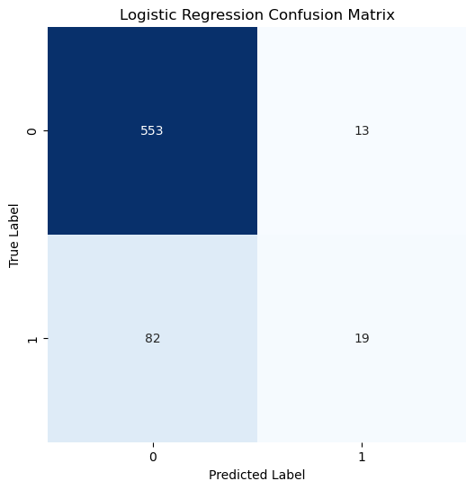

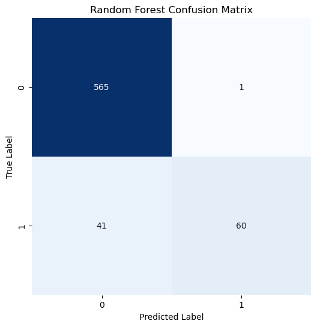

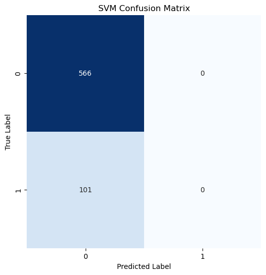

```python
# Confusion Matrix for Logistic Regression
plt.figure(figsize=(6, 6))
sns.heatmap(confusion_matrix(y_test, y_pred_logreg), annot=True, fmt='d', cmap='Blues', cbar=False)
plt.title('Logistic Regression Confusion Matrix')
plt.ylabel('True Label')
plt.xlabel('Predicted Label')
plt.show()

# Confusion Matrix for Random Forest
plt.figure(figsize=(6, 6))
sns.heatmap(confusion_matrix(y_test, y_pred_rf), annot=True, fmt='d', cmap='Blues', cbar=False)
plt.title('Random Forest Confusion Matrix')
plt.ylabel('True Label')
plt.xlabel('Predicted Label')
plt.show()

# Confusion Matrix for SVM
plt.figure(figsize=(6, 6))
sns.heatmap(confusion_matrix(y_test, y_pred_svm), annot=True, fmt='d', cmap='Blues', cbar=False)
plt.title('SVM Confusion Matrix')
plt.ylabel('True Label')
plt.xlabel('Predicted Label')
plt.show()
```

Evaluating the Models

Logistic Regression Evaluation

```python
from sklearn.metrics import accuracy_score, precision_score, recall_score, f1_score, roc_auc_score, confusion_matrix

# Evaluate Logistic Regression
accuracy_logreg = accuracy_score(y_test, y_pred_logreg)
precision_logreg = precision_score(y_test, y_pred_logreg)
recall_logreg = recall_score(y_test, y_pred_logreg)
f1_logreg = f1_score(y_test, y_pred_logreg)
roc_auc_logreg = roc_auc_score(y_test, y_pred_logreg)

# Display the evaluation metrics for Logistic Regression
print(f'Logistic Regression - Accuracy: {accuracy_logreg:.4f}')
print(f'Precision: {precision_logreg:.4f}')
print(f'Recall: {recall_logreg:.4f}')
print(f'F1-score: {f1_logreg:.4f}')
print(f'ROC AUC: {roc_auc_logreg:.4f}')

# Confusion Matrix
conf_matrix_logreg = confusion_matrix(y_test, y_pred_logreg)
print(f'Confusion Matrix for Logistic Regression:\n{conf_matrix_logreg}')
```

```
Logistic Regression - Accuracy: 0.8576
Precision: 0.5938
Recall: 0.1881
F1-score: 0.2857
ROC AUC: 0.5826
Confusion Matrix for Logistic Regression:
[[553  13]
 [ 82  19]]
```

Random Forest Evaluation

```python
# Evaluate Random Forest
accuracy_rf = accuracy_score(y_test, y_pred_rf)
precision_rf = precision_score(y_test, y_pred_rf)
recall_rf = recall_score(y_test, y_pred_rf)
f1_rf = f1_score(y_test, y_pred_rf)
roc_auc_rf = roc_auc_score(y_test, y_pred_rf)

# Display the evaluation metrics for Random Forest
print(f'\nRandom Forest - Accuracy: {accuracy_rf:.4f}')
print(f'Precision: {precision_rf:.4f}')
print(f'Recall: {recall_rf:.4f}')
print(f'F1-score: {f1_rf:.4f}')
print(f'ROC AUC: {roc_auc_rf:.4f}')

# Confusion Matrix
conf_matrix_rf = confusion_matrix(y_test, y_pred_rf)
print(f'Confusion Matrix for Random Forest:\n{conf_matrix_rf}')
```

```
Random Forest - Accuracy: 0.9370
Precision: 0.9836
Recall: 0.5941
F1-score: 0.7407
ROC AUC: 0.7961
Confusion Matrix for Random Forest:
[[565   1]
 [ 41  60]]
```

SVM Evaluation

```python
# Evaluate SVM
accuracy_svm = accuracy_score(y_test, y_pred_svm)
precision_svm = precision_score(y_test, y_pred_svm)
recall_svm = recall_score(y_test, y_pred_svm)
f1_svm = f1_score(y_test, y_pred_svm)
roc_auc_svm = roc_auc_score(y_test, y_pred_svm)

# Display the evaluation metrics for SVM
print(f'\nSVM - Accuracy: {accuracy_svm:.4f}')
print(f'Precision: {precision_svm:.4f}')
print(f'Recall: {recall_svm:.4f}')
print(f'F1-score: {f1_svm:.4f}')
print(f'ROC AUC: {roc_auc_svm:.4f}')

# Confusion Matrix
conf_matrix_svm = confusion_matrix(y_test, y_pred_svm)
print(f'Confusion Matrix for SVM:\n{conf_matrix_svm}')
```

```
SVM - Accuracy: 0.8486
Precision: 0.0000
Recall: 0.0000
F1-score: 0.0000
ROC AUC: 0.5000
Confusion Matrix for SVM:
[[566   0]
 [101   0]]
```

Display Metrics in a Comparison Table

```python
# Model Comparison Table
model_comparison = {
    'Model': ['Logistic Regression', 'Random Forest', 'SVM'],
    'Accuracy': [accuracy_logreg, accuracy_rf, accuracy_svm],
    'Precision': [precision_logreg, precision_rf, precision_svm],
    'Recall': [recall_logreg, recall_rf, recall_svm],
    'F1-score': [f1_logreg, f1_rf, f1_svm],
    'ROC AUC': [roc_auc_logreg, roc_auc_rf, roc_auc_svm]
}

comparison_df = pd.DataFrame(model_comparison)
print("\nModel Evaluation Comparison:")
print(comparison_df)
```

```
Model Evaluation Comparison:
                 Model  Accuracy  Precision    Recall  F1-score   ROC AUC
0  Logistic Regression  0.857571   0.593750  0.188119  0.285714  0.582575
1        Random Forest  0.937031   0.983607  0.594059  0.740741  0.796146
2                  SVM  0.848576   0.000000  0.000000  0.000000  0.500000
```

Decision Tree Model

```python
from sklearn.tree import DecisionTreeClassifier
from sklearn.metrics import accuracy_score, precision_score, recall_score, f1_score, roc_auc_score, confusion_matrix
from sklearn import tree
```

Train the Decision Tree Model

```python
# Instantiate the Decision Tree model
dt_model = DecisionTreeClassifier(random_state=42)

# Fit the model on the training data
dt_model.fit(X_train, y_train)

# Make predictions on the test data
y_pred_dt = dt_model.predict(X_test)
```

Model Evaluation

```python
# Evaluate the Decision Tree
accuracy_dt = accuracy_score(y_test, y_pred_dt)
precision_dt = precision_score(y_test, y_pred_dt)
recall_dt = recall_score(y_test, y_pred_dt)
f1_dt = f1_score(y_test, y_pred_dt)
roc_auc_dt = roc_auc_score(y_test, y_pred_dt)

# Display the evaluation metrics for Decision Tree
print(f'Decision Tree - Accuracy: {accuracy_dt:.4f}')
print(f'Precision: {precision_dt:.4f}')
print(f'Recall: {recall_dt:.4f}')
print(f'F1-score: {f1_dt:.4f}')
print(f'ROC AUC: {roc_auc_dt:.4f}')

# Confusion Matrix
conf_matrix_dt = confusion_matrix(y_test, y_pred_dt)
print(f'Confusion Matrix for Decision Tree:\n{conf_matrix_dt}')
```

```
Decision Tree - Accuracy: 0.9160
Precision: 0.7103
Recall: 0.7525
F1-score: 0.7308
ROC AUC: 0.8489
Confusion Matrix for Decision Tree:
[[535  31]
 [ 25  76]]
```

Visualization of the Decision Tree

[figure not shown]

```python
# Plot the Decision Tree
plt.figure(figsize=(15, 10))
tree.plot_tree(dt_model, filled=True, feature_names=X_train.columns, class_names=['No Churn', 'Churn'], rounded=True, fontsize=10)
plt.title("Decision Tree Visualization")
plt.show()
```

```python
# Model comparison dictionary
model_comparison = {
    'Model': ['Logistic Regression', 'Random Forest', 'SVM', 'Decision Tree'],
    'Accuracy': [accuracy_logreg, accuracy_rf, accuracy_svm, accuracy_dt],
    'Precision': [precision_logreg, precision_rf, precision_svm, precision_dt],
    'Recall': [recall_logreg, recall_rf, recall_svm, recall_dt],
    'F1-score': [f1_logreg, f1_rf, f1_svm, f1_dt],
    'ROC AUC': [roc_auc_logreg, roc_auc_rf, roc_auc_svm, roc_auc_dt]
}

# Create a DataFrame to display the model comparison
comparison_df = pd.DataFrame(model_comparison)

# Print the comparison table
print("\nModel Evaluation Comparison:")
print(comparison_df)
```

```
Model Evaluation Comparison:
                 Model  Accuracy  Precision    Recall  F1-score   ROC AUC
0  Logistic Regression  0.857571   0.593750  0.188119  0.285714  0.582575
1        Random Forest  0.937031   0.983607  0.594059  0.740741  0.796146
2                  SVM  0.848576   0.000000  0.000000  0.000000  0.500000
3        Decision Tree  0.916042   0.710280  0.752475  0.730769  0.848852
```

# CONCLUSION

# Random Forest

# Decision Tree

Is the second best with:Accuracy 91.60% - High accuracy and overall good performance. Precision: 71.03% - It predicts positives correctly with a good precision. Recall: 75.25% - It successfully identifies a large proportion of the positive cases Making it a good option if identifying positive cases is crucial.

# Logistic Regression

Logistic Regression has good accuracy but struggles with low recall and F1-score, so it may not be ideal if identifying positives is important. Accuracy: 85.76% - It has a decent accuracy but struggles with identifying positive cases, as reflected in its low recall (18.81%). Precision: 59.38% - It predicts positives correctly 59.38% of the time. Recall: 18.81% - It misses many positive instances.

# Support Vector Machine (SVM)

Is the worst Model here SVM is not usable as it fails to predict any positive cases, leading to zero precision, recall, and F1-score. Accuracy: 84.86% - Similar to Logistic Regression, but this is misleading as the model fails to identify any positives. Precision, Recall, and F1-Score: All are 0 because the model never predicts a positive class, making it useless in its current state. ROC AUC: 50.00% - It performs as well as random guessing.

# Hyperparameter Tuning above models

Random Forest Hyperparameter Tuning

```python
from sklearn.ensemble import RandomForestClassifier
from sklearn.model_selection import GridSearchCV

# Hyperparameter grid for Random Forest
param_grid_rf = {
    'n_estimators': [100, 200, 300],
    'max_depth': [10, 20, None],
    'min_samples_split': [2, 5, 10],
    'min_samples_leaf': [1, 2, 4],
    'max_features': ['auto', 'sqrt'],
    'bootstrap': [True, False]
}

# Initialize Random Forest model
rf = RandomForestClassifier()

# Use GridSearchCV to search the best parameters
grid_rf = GridSearchCV(estimator=rf, param_grid=param_grid_rf, cv=5, scoring='accuracy')

# Fit the grid search to the data
grid_rf.fit(X_train, y_train)

# Best hyperparameters
print("Best Parameters:", grid_rf.best_params_)
```

[output not shown]

Decision Tree Hyperparameter Tuning

```python
from sklearn.tree import DecisionTreeClassifier
from sklearn.model_selection import GridSearchCV

# Hyperparameter grid for Decision Tree
param_grid_dt = {
    'max_depth': [10, 20, None],
    'min_samples_split': [2, 5, 10],
    'min_samples_leaf': [1, 2, 4],
    'max_features': ['auto', 'sqrt'],
    'criterion': ['gini', 'entropy']
}

# Initialize Decision Tree model
dt = DecisionTreeClassifier()

# Use GridSearchCV to search the best parameters
grid_dt = GridSearchCV(estimator=dt, param_grid=param_grid_dt, cv=5, scoring='accuracy')

# Fit the grid search to the data
grid_dt.fit(X_train, y_train)

# Best hyperparameters
print("Best Parameters:", grid_dt.best_params_)
```

```
Best Parameters: {'criterion': 'gini', 'max_depth': 10, 'max_features': 'sqrt', 'min_samples_leaf': 2, 'min_samples_split': 10}
```

# Recommendations

Preferred Model: Random Forest

For a simpler, more interpretable model, Logistic Regression might still be useful. However, its low recall and F1-score indicate that improvements are needed. Consider fine-tuning hyperparameters or incorporating additional features that might help improve recall and overall performance. SVM:

SVM should be discarded for this particular task. The model’s failure to predict any churn cases and its poor ROC AUC score suggest that it is not suitable for this dataset. You could consider revisiting SVM after extensive tuning, but for now, Random Forest provides a much better solution.

# Next Steps

2.Address Class Imbalance Many churn models suffer from class imbalance (where the number of churned customers is much smaller than non-churned customers). This could explain some of the low recall and performance issues, especially with Logistic Regression and SVM

3.Model Evaluation and Validation All models should be evaluated using cross-validation to ensure their performance is robust and not subject to overfitting. Since the data might be imbalanced, precision, recall, and F1-score should be prioritized, especially recall to ensure churned customers are being detected.

4.Customer Retention Strategies Use the churn prediction model to create actionable strategies for customer retention. For instance, if the model identifies high-risk customers, a targeted marketing campaign can be launched to offer promotions, improve customer service, or address specific customer pain points

5.Continuous Improvement & Feedback Loop Model Drift: Over time, customer behavior might change. Implement a feedback loop to continuously update and improve the model.

6.Business Collaboration and Insights Collaborate with the marketing, customer service, and product teams to ensure that churn insights are used effectively in business strategie